# Practical Machine Learning Project

Kelvin

21 Jun 2015

## 1. Introduction

Human Activity Recognition (HAR) devices emergence as a wear technology has resulted in development of applications focusing on the result of executing an activity. The data collected by the app can then be used for a variety of purpose e.g. correct posture to prevent injuries, optimize traininga and etc.

This project focus on using data collected from HAR devices to predict if an activity (e.g. dumbbell lifting) is performed in an expected manner.

## 2. Setup

Environment: The four HAR devices were attached to the test subject to detect motions in the following place:  
- A gyro sensor on the Dumbbell  
- A glove sensor worn around the Wrist  
- An arm-band sensor worn around the Arm  
- A belt sensor worn around Waist

In this test, six human test subjects are requested to do dumbbell lifting in five different ways as follow: A. Proper and correct execution of dumbbell lifting  
B. Throwing the elbows to the front  
C. Lifting the dumbbell only halfway  
D. Lowering the dumbbell only halfway  
E. Throwing the hips to the front

To take the measurement, one set of 10 repetitions for each of the five different ways above were executed by the 6 test subjects. The data is then saved in a CSV file.

## 3. Exploratory Data Analysis

The dataset has **19622** observations and **160** variables.

```r
library(caret)
require(randomForest)
pmltrain <- read.csv("pml-training.csv", head=T)
```

### 3.1 Cleaning and Filtering Data

In the CSV, there are some variables which have no value or NAs on most of the observations because these variables contain the max, var, stddev, min, etc. for a set of repetitions, let’s filter off these variables. In addition, the first seven columns (id, names, timestamps, repetition window indicators) does not seems relevant so it will also be filtered.

```r
x <- as.numeric()
for(i in 1:ncol(pmltrain)) { if(pmltrain[1,i]=="" | is.na(pmltrain[1,i])) x <- c(x, i) }
pmltrain <- pmltrain[-x]; pmltrain <- pmltrain[-c(1:7)]
```

## 4. Data Slicing

The dataset is split into 60% (training) 40% (testing) partitions. A seed is then set so that the same results can be reproduced.  
The prediction model is trained using the training partition to achieve a satisfactory result before applying to the testing partition.

```r
set.seed(5)
inTrain <- createDataPartition(y=pmltrain$classe, p=0.6, list=F)
training <- pmltrain[inTrain,]
testing <- pmltrain[-inTrain,]
```

## 5. Model Fitting

The model picked for this test is Random Forest algorithm as this is the most accurate model among some of other model. To improve accuracy and peformance of the selected model, the data is first preprocessed within caret ‘train’ function using Principal Components Analysis (PCA). **10 fold cross validation** is performed within caret ‘train’ function to improve the accuracy.

```r
set.seed(5)
modelFit <- train(classe ~ ., data=training, preProcess=c("pca"), trControl=trainControl(method="cv"), method="rf")
```

The optimal model was selected based on Accuracy. This optimal model uses mtry of 2 and yields an accuracy of **96.77%** sampling on the training data.

```
## Random Forest
##
## 11776 samples
##    52 predictor
##     5 classes: 'A', 'B', 'C', 'D', 'E'
##
## Pre-processing: principal component signal extraction, scaled, centered
## Resampling: Cross-Validated (10 fold)
##
## Summary of sample sizes: 10598, 10598, 10598, 10598, 10599, 10599, ...
##
## Resampling results across tuning parameters:
##
##   mtry  Accuracy   Kappa      Accuracy SD  Kappa SD
##    2    0.9676458  0.9590658  0.004132234  0.005234422
##   27    0.9541442  0.9419865  0.006352655  0.008039391
##   52    0.9541437  0.9419836  0.005898122  0.007463937
##
## Accuracy was used to select the optimal model using  the largest value.
## The final value used for the model was mtry = 2.
```

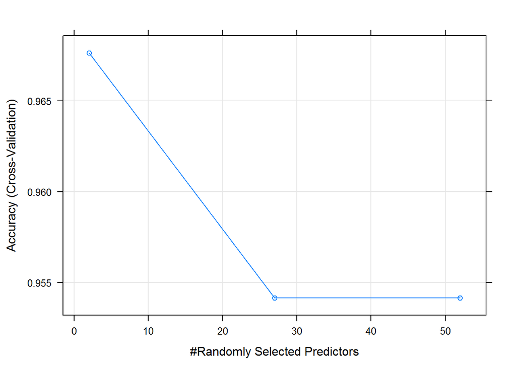

### 5.1 Out of Sample Error

Based on the results, Accurary was the criteria for selecting the optimal model. This model uses mtry of 2 and has an accuracy of **96.77%** sampling on the training data.

```r
## Using the model to predict on testing data excluding the 'classe' column
ptest <- predict(modelFit, testing[,-53])
confusionMatrix(ptest, testing$classe)
```

```
## Confusion Matrix and Statistics
##
##           Reference
## Prediction    A    B    C    D    E
##          A 2217   20    3    5    1
##          B    4 1471   25    5    5
##          C    7   26 1329   50   11
##          D    4    0   10 1225   14
##          E    0    1    1    1 1411
##
## Overall Statistics
##
##                Accuracy : 0.9754
##                  95% CI : (0.9717, 0.9787)
##     No Information Rate : 0.2845
##     P-Value [Acc > NIR] : < 2.2e-16
##
##                   Kappa : 0.9689
##  Mcnemar's Test P-Value : 1.449e-10
##
## Statistics by Class:
##
##                      Class: A Class: B Class: C Class: D Class: E
## Sensitivity            0.9933   0.9690   0.9715   0.9526   0.9785
## Specificity            0.9948   0.9938   0.9855   0.9957   0.9995
## Pos Pred Value         0.9871   0.9742   0.9339   0.9777   0.9979
## Neg Pred Value         0.9973   0.9926   0.9939   0.9907   0.9952
## Prevalence             0.2845   0.1935   0.1744   0.1639   0.1838
## Detection Rate         0.2826   0.1875   0.1694   0.1561   0.1798
## Detection Prevalence   0.2863   0.1925   0.1814   0.1597   0.1802
## Balanced Accuracy      0.9941   0.9814   0.9785   0.9741   0.9890
```

## 6. Final Prediction - Validatiing the dataset

The prediction is now applied on the validation dataset which contains 20 test cases It is important to tidy and filtered the validation data set before applying to test cases for predicting the results.

```r
## Read validation data set from file
validation <- read.csv("pml-testing.csv", header=T)

## Perform data filtering and tidying as per training/testing data set
x <- as.numeric()
for(i in 1:ncol(validation)) { if(validation[1,i]=="" | is.na(validation[1,i])) x <- c(x, i) }
validation <- validation[-x]; validation <- validation[-c(1:7)]

## Predict on validation data set excluding the last column which is problem_id
(pred <- predict(modelFit, validation[,-53]))
```

```
##  [1] B A B A A E D B A A A C B A E E A B B B
## Levels: A B C D E
```